# PSL: Tree-Based (Regression) Models

## 4. Random Forests

We now move to ensemble methods. We start with `RandomForestRegressor` from `scikit-learn`. We also split the data in training and testing data sets.

```python
X_train, X_test, y_train, y_test = train_test_split(
    X, y, test_size=0.3, random_state=598)
```

### Model Fitting

To fit the model, we use the `RandomForestRegressor` function. Our goal is to predict the `quality` using all the other columns in the data matrix as potential predictors.

- `n_estimators` is the number of trees (equivalent to `ntree` in R).
- `max_features` is the number of variables to consider at each split (equivalent to `mtry`). The R `randomForest` package defaults to p/3 for regression. The `scikit-learn` default is `p`, so we will explicitly set it to `'sqrt'` or `1/3` to be comparable.
- `oob_score=True` enables the calculation of the out-of-bag error, which is a reliable estimate of the model's performance on unseen data.

```python
rf_wines = RandomForestRegressor(
    n_estimators=400,
    max_features=1./3.,  # p/3 rule
    oob_score=True,
    random_state=598,
    n_jobs=-1  # Use all available cores
)
rf_wines.fit(X_train, y_train)
```

```
RandomForestRegressor(max_features=0.3333333333333333, n_estimators=400,
                      n_jobs=-1, oob_score=True, random_state=598)
```

We can use the fitted model to make predictions, and we can calculate the average test error:

```python
test_mse = mean_squared_error(rf_wines.predict(X_test), y_test)
print(f"Test Set MSE: {test_mse:.4f}")
```

```
Test Set MSE: 0.3912
```

If we think about the training error, then the random forest approach leads us to two types of training errors: one based on the prediction function (using the training data) and the other one based on the out-of-bag samples.

```python
train_mse = mean_squared_error(rf_wines.predict(X_train), y_train)
print(f"Training Set MSE: {train_mse:.4f}")
```

```
Training Set MSE: 0.0498
```

We can see that the training error is significantly smaller compared to the prediction error.

```python
oob_mse = mean_squared_error(rf_wines.oob_prediction_, y_train)
print(f"Out-of-Bag (OOB) MSE: {oob_mse:.4f}")
```

```
Out-of-Bag (OOB) MSE: 0.3700
```

The error based on the out-of-bag sample is closer to the testing error and a more reliable estimator to the model’s generalization performance.

### Performance Plots

We can visualize how the OOB error changes as more trees are added to the forest. This helps confirm if we have used enough trees.

Unlike `randomForest` in R, `RandomForestRegressor` does not have a built-in function for this. We need to import an internal function to help us finding the OOB samples, and then use those to compute the cumulative predicitions and errors.

```python
from sklearn.ensemble._forest import _generate_unsampled_indices

n_samples = X_train.shape[0]
n_samples_bootstrap = n_samples  # since we did not set max_samples
n_trees_range = np.arange(1, rf_wines.n_estimators + 1)

# get OOB predictions from each tree
oob_preds_cumulative = np.empty((n_samples, rf_wines.n_estimators))
oob_preds_cumulative[:] = np.nan
for i, tree in enumerate(rf_wines.estimators_):
    # get indices of OOB samples for this tree
    oob_indices = _generate_unsampled_indices(
        tree.random_state, n_samples, n_samples_bootstrap)
    oob_pred = tree.predict(X_train.iloc[oob_indices].values)
    oob_preds_cumulative[oob_indices, i] = oob_pred

# compute cumulative mean predictions
# cumulative numbers of predicitions
oob_count_cumulative = (1 - np.isnan(oob_preds_cumulative)).cumsum(axis=1)
# division by 0 will occur, before the first prediction appear
with np.errstate(divide='ignore', invalid='ignore'):
    oob_mean_pred = np.nancumsum(
        oob_preds_cumulative, axis=1) / oob_count_cumulative

# compute the OOB MSE with broadcast
oob_mse = np.nanmean(
    (oob_mean_pred.T - y_train.values[:, None].T).T ** 2., axis=0)
```

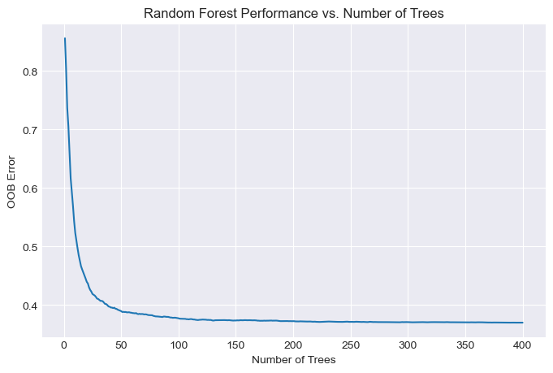

```python
plt.figure(figsize=(8, 5))
plt.plot(n_trees_range, oob_mse)
plt.xlabel("Number of Trees")
plt.ylabel("OOB Error")
plt.title("Random Forest Performance vs. Number of Trees")
plt.show()
```

The plot shows that the model's performance improves rapidly with the initial addition of trees but starts to plateau beyond a certain point. This suggests that adding more trees does not lead to overfitting, although one could potentially achieve similar performance with fewer trees.

### Variable Importance

Random Forest can also measure the importance of each feature. We will plot the impurity-based importance (`feature_importances_`), which is computed using the mean decrease in impurity (Gini for classification, MSE for regression). This is equivalent to `IncNodePurity` in R.

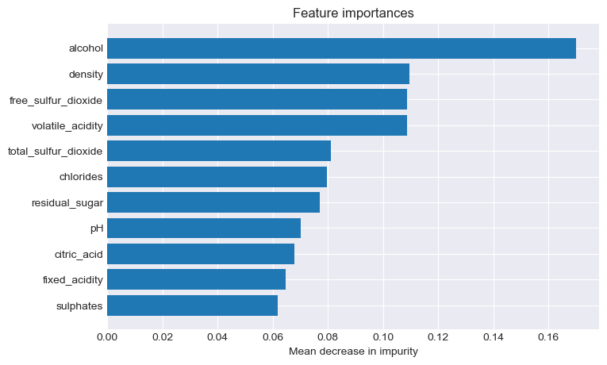

```python
# sorted impurity-based feature importance
imp_id = np.argsort(rf_wines.feature_importances_)

plt.figure(figsize=(8, 5))
plt.barh(X_train.columns[imp_id], rf_wines.feature_importances_[imp_id])
plt.title("Feature importances")
plt.xlabel("Mean decrease in impurity")
plt.ylabel("")
fig.tight_layout()
```

## 5. Gradient Boosting Machines (GBM)

Before running a GBM model, we need to tune the following hyperparameters:

- **`loss`**: loss function to be optimized. `'squared_error'` for regression.
- **`n_estimators`**: number of trees.
- **`learning_rate`**: also known as the shrinkage factor (default = 0.1).
- **`subsample`**: fraction of the training data used for learning (default = 1.0).
- **`max_depth`**: depth of individual trees (default = 3).

```python
# Fit the first GBM model (similar to the R example)
gbm_wines = GradientBoostingRegressor(
    n_estimators=100,
    learning_rate=1.0,  # High learning rate
    max_depth=3,
    subsample=1.0,
    random_state=598
)
gbm_wines.fit(X_train, y_train)
```

```
GradientBoostingRegressor(learning_rate=1.0, random_state=598)
```

### Finding the Optimal Number of Trees

We can plot the model's performance on a validation set (held out from the training data) to find the optimal number of trees and prevent overfitting. `GradientBoostingRegressor` of `scikit-learn` does not have a built-in cross-validation, so we will evaluate the model'’'s performance on the test data against the number of trees.

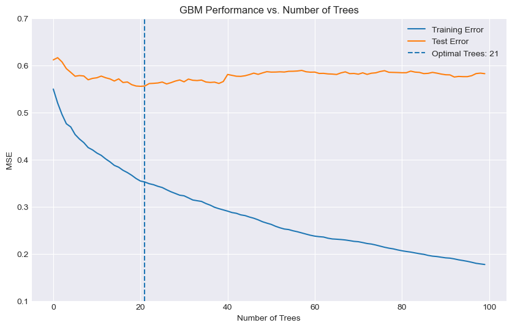

```python
# The validation scores are stored in the train_score_ attribute
train_error = gbm_wines.train_score_
test_error = np.zeros(100)
for i, y_pred in enumerate(gbm_wines.staged_predict(X_test)):
    test_error[i] = mean_squared_error(y_test, y_pred)

opt_size = np.argmin(test_error) + 1  # Add 1 because of 0-based indexing

plt.figure(figsize=(10, 6))
plt.plot(train_error, label='Training Error')
plt.plot(test_error, label='Test Error')
plt.axvline(opt_size, linestyle='--',
            label=f'Optimal Trees: {opt_size}')
plt.ylim(0.1, 0.7)
plt.xlabel("Number of Trees")
plt.ylabel("MSE")
plt.title("GBM Performance vs. Number of Trees")
plt.legend()
plt.show()
```

We can change the tuning parameters and fit a new GBM:

```python
gbm_wines2 = GradientBoostingRegressor(
    n_estimators=1000,
    learning_rate=0.1,
    max_depth=3,
    subsample=0.5,
    random_state=598,
    tol=0.001
)
gbm_wines2.fit(X_train, y_train)
```

```
GradientBoostingRegressor(n_estimators=1000, random_state=598, subsample=0.5,
                          tol=0.001)
```

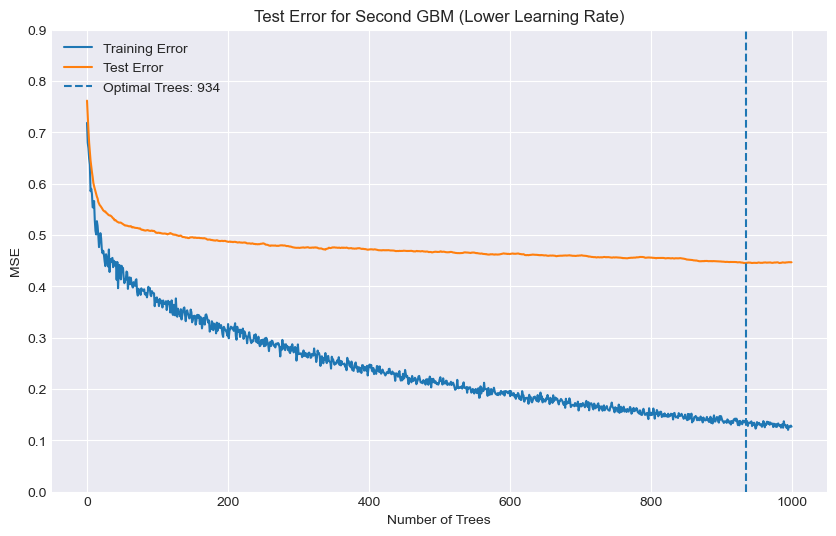

```python
# Evaluate test error at each stage
train_error2 = gbm_wines2.train_score_
test_error2 = np.zeros(1000)
for i, y_pred in enumerate(gbm_wines2.staged_predict(X_test)):
    test_error2[i] = mean_squared_error(y_test, y_pred)

# Find optimal number of trees from validation data
opt_size2 = np.argmin(test_error2) + 1

size_2 = np.arange(1, len(test_error2) + 1)

plt.figure(figsize=(10, 6))
plt.plot(train_error2, label='Training Error')
plt.plot(test_error2, label='Test Error')
plt.axvline(opt_size2, linestyle='--',
            label=f'Optimal Trees: {opt_size2}')
plt.ylim(0, 0.9)
plt.xlabel("Number of Trees")
plt.ylabel("MSE")
plt.title("Test Error for Second GBM (Lower Learning Rate)")
plt.legend()
plt.show()
```

### Variable Importance

We can still quantify the variable importance:

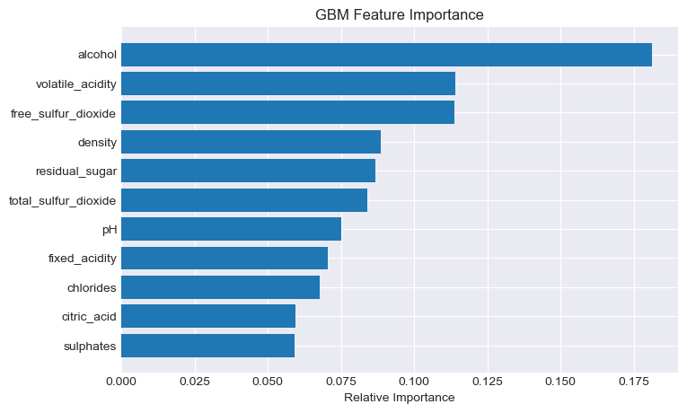

```python
gbm_importance = pd.Series(gbm_wines2.feature_importances_, index=X.columns).sort_values()

plt.figure(figsize=(8, 5))
plt.barh(gbm_importance.index, gbm_importance)
plt.title("GBM Feature Importance")
plt.xlabel("Relative Importance")
plt.ylabel("")
plt.show()
```